# COMPSCIX 415.2 Homework 5/Midterm Dinglin Huo 2019/03/05

Dinglin Huo

March 5,2019

## RStudio and R Markdown (3 points)

## The tidyverse packages (3 points)

### 1.Can you name which package is associated with each task below?

Plotting - ggplot Data munging/wrangling – dplyr and tidyr Reshaping (speading and gathering) data -dplyr Importing/exporting data - readr

### 2.Now can you name two functions that you’ve used from each package that you listed above for these tasks?

Plotting - geom_bar() geom_point() Data munging/wrangling - filter() summarize() Reshaping data - gather() spread() Importing/exporting data - read_csv() write_csv()

## R Basics (1.5 points)

### 1.Fix this code with the fewest number of changes possible so it works:

```r
my_data <- c(1,2,3)
my_data
```

```
## [1] 1 2 3
```

### 2.Fix this code so it works:

```r
my_string <- c("has","an", "error","in", "it")
my_string
```

```
## [1] "has"   "an"    "error" "in"    "it"
```

### 2.Look at the code below and comment on what happened to the values in the vector:

It turned all the value to varchar

```r
my_vector <- c(1, 2, '3', '4', 5)
my_vector
```

```
## [1] "1" "2" "3" "4" "5"
```

## Data import/export (3 points)

### 1.Download the rail_trail.txt file from Canvas (in the Midterm Exam section) and successfully import it into R. Prove that it was imported successfully by including your import code and taking a glimpse of the result.

### 2.Export the file into a comma-separated file and name it “rail_trail.csv”. Make sure you define the path correctly so that you know where it gets saved. Then reload the file. Include your export and import code and take another glimpse.

```r
library(tidyverse)
file_path <- 'rail_trail.txt'
text_data <-read.delim(file_path)
glimpse(text_data)
```

```
## Observations: 90
## Variables: 1
## $ hightemp.lowtemp.avgtemp.spring.summer.fall.cloudcover.precip.volume.weekday <fct> ...
```

```r
write_delim(text_data,delim=',', path ='rail_trail.csv')
```

## Visualization (6 points)

### 1.Critique this graphic: give only three examples of what is wrong with this graphic. Be concise.

Answer: 1.each row is supose to be an age category, the total horizontally doesnt add up to 100, which is quite confusing. 2. the Yes and No coloumn, only one is enough. 3.coloring seems off, age groups is not coloured at all, while genders are colored.

### 2.Reproduce this graphic using the diamonds data set.

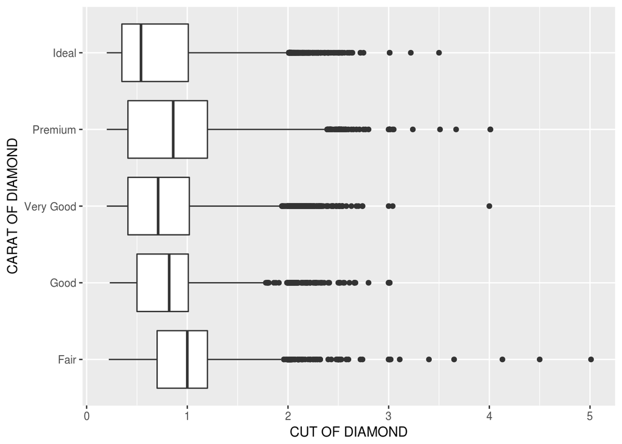

```r
ggplot(data= diamonds ,mapping = aes(x= cut, y =carat ) )+
  geom_boxplot()+
  coord_flip()+
    xlab("CARAT OF DIAMOND") + ylab("CUT OF DIAMOND")
```

### 3.The previous graphic is not very useful. We can make it much more useful by changing one thing about it. Make the change and plot it again.

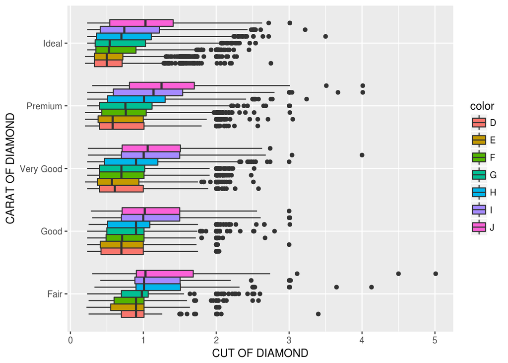

```r
ggplot(data= diamonds ,mapping = aes(x= cut, y =carat,fill= color) )+
  geom_boxplot()+
  coord_flip()+
  xlab("CARAT OF DIAMOND") + ylab("CUT OF DIAMOND")
```

## Data munging and wrangling (6 points)

### 1.Is this data “tidy”? If yes, leave it alone and go to the next problem. If no, make it tidy. Note: this data set is called table2 and is available in the tidyverse package. It should be ready for you to use after you’ve loaded the tidyverse package.

Yes

### 2.Create a new column in the diamonds data set called price_per_carat that shows the price of each diamond per carat (hint: divide). Only show me the code, not the output.

### 3.For each cut of diamond in the diamonds data set, how many diamonds, and what proportion, have a price > 10000 and a carat < 1.5? There are several ways to get to an answer, but your solution must use the data wrangling verbs from the tidyverse in order to get credit.

Do the results make sense? Why? Do we need to be wary of any of these numbers? Why?

## EDA (6 points)

### 1.During what time period is this data from?

2000-2015 ### 2.How many cities are represented? 46 ### 3.Which city, month and year had the highest number of sales? Houston 2015 ### 4.What kind of relationship do you think exists between the number of listings and the number of sales? Check your assumption and show your work. Positive correlation

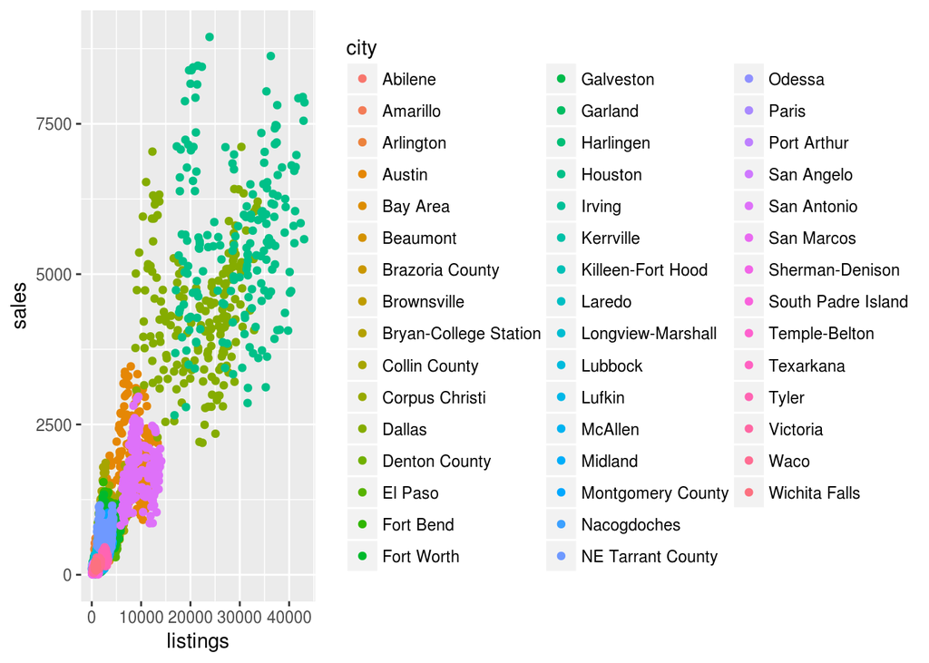

```r
library(ggplot2)

ggplot(data = txhousing, mapping=aes(x=listings, y=sales, color=city))+
 geom_point()
```

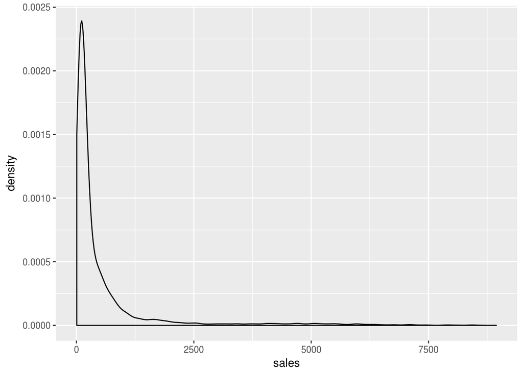

```r
ggplot(data = txhousing) +
  geom_density(mapping = aes(x = sales), adjust = 2)
```

### 5.What proportion of sales is missing for each city?

Sales more than 2500 ### 6.Looking at only the cities and months with greater than 500 sales: Are the distributions of the median sales price (column name median), when grouped by city, different? The same? Show your work.

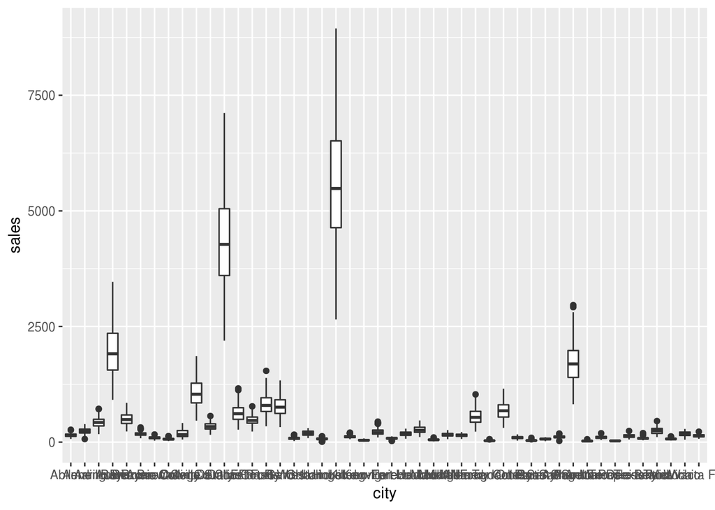

```r
ggplot(data = txhousing) +
  geom_boxplot(mapping = aes(x = city, y =sales ))
```

Any cities that stand out that you’d want to investigate further?

Why might we want to filter out all cities and months with sales less than 500?

## Git and Github (1.5 points)

To demonstrate your use of git and Github, at the top of your document put a hyperlink to your Github repository.

Once you are finished with your midterm, commit your final changes with the comment “finished the midterm - woohoo” and push your R Markdown file and your html or pdf file to Github.